# Machine Learning aided Record Linkage

## Group Components

- **Francesco Porto** f.porto2@campus.unimib.it (816042)
- **Francesco Stranieri** f.stranieri1@campus.unimib.it (816551)
- **Mattia Vincenzi** m.vincenzi14@campus.unimib.it (860579)

## Abstract

Record Linkage is the process of finding records in one or more datasets that refer to the same entity across different data sources. Traditionally, it is done by applying comparison rules between pairs of attributes from each dataset. In this project we investigate some possible Machine Learning applications to Record Linkage (and Data deduplication) by doing **two different experiments**. In the first experiment, we compare two different Indexing methods (Full vs Block) to figure out which one works better for our models in terms of time and quality of results. In the second experiment, we try to investigate the re-usability of the models we create, training on a dataset and testing on the other, and their viability in real-case scenarios.

## Python Record Linkage Toolkit

Throughout the project, we make use of a Python library called ["Python Record Linkage Toolkit"](https://github.com/J535D165/recordlinkage/blob/master/docs/index.rst), which provides a simple framework to facilitate the process of Record Linkage. In the context of this library, the Record Linkage process is divided into 5 steps:

- **Preprocessing (optional)**: clean the datasets in order to improve the odds of finding matches.
- **Indexing**: create record pairs (R1, R2) such that R1 belongs to the first dataset and R2 belongs to the second one. Such pairs are called "*candidate links*", and can be obtained via different methods (e.g. Full Index or Block Index)
- **Comparison**: compare record pairs via different metrics and thresholds, in order to obtain measures of similarity between each pair. Note that no cardinality reduction is performed in this phase.
- **Classification**: classify record pairs, according to their measure of similarity, into matches or non-matches. It can be done either by using a deterministic approach or different Machine Learning algorithms.
- **Evaluation**: evaluate the results of the Classification phase via Confusion Matrices.

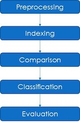

### Helper Functions

We have defined a few helper functions that allow us to streamline the Record Linkage process:

- **Indexing_dataset** : given two datasets, returns the result of the indexing process (either *full* or *block*) on the given attributes
- **Compare_records** : given two datasets, a set of rules specifying how to compare some attributes, and a list of attributes that must match exactly, returns a multi index containing the comparisons' results.
- **Evaluate_results** : returns a confusion matrix of a given classification method; also returns its precision, f-score and recall

# Experiment 1: Comparison between Full Index and Block Index

In this experiment we present two examples of Record Linkage, the first one using a **Full Index**, that is we make the cartesian product of the records in the first dataset and the records in the second one; the second one uses **Blocking**, that only finds a subset of the cartesian product.

## Part 1: Using a Full Index

### Dataset description

We use the FEBRL (Freely Extensible Biomedical Record Linkage) dataset since it provides the *true links* for optimal Record Linkage. The paper used as reference is available [here](http://citeseerx.ist.psu.edu/viewdoc/download?doi=10.1.1.481.8577&rep=rep1&type=pdf).

```python
from recordlinkage.datasets import load_febrl4
```

This dataset contains 10000 records (5000 originals and 5000 duplicates, with one duplicate per original); the originals have been split from the duplicates into dataset4a.csv (containing the 5000 original records) and dataset4b.csv (containing the 5000 duplicate records).

```
Loading data...
5000 records in dataset A
5000 records in dataset B
5000 links between dataset A and B
```

We take a first look at the dataset. It contains auto-generated records about patients. There are 11 fields:

- **rec_id**: the id of the record
- **given_name**: the name of the patient
- **street_number**: the street number of the patient's house
- **address_1**: the road where the patient lives
- **address_2**: the city where the patient lives
- **suburb**: the suburb in the city where the patient lives
- **postcode**: the postcode of the city where the patient lives
- **state**: the state where the patient lives
- **date_of_birth**: the date of birth of the patient
- **soc_sec_id**: the social security number of the patient

| rec_id | given_name | surname | street_number | address_1 | address_2 | suburb | postcode | state | date_of_birth | soc_sec_id |
| --- | --- | --- | --- | --- | --- | --- | --- | --- | --- | --- |
| rec-1070-org | michaela | neumann | 8 | stanley street | miami | winston hills | 4223 | nsw | 19151111 | 5304218 |
| rec-1016-org | courtney | painter | 12 | pinkerton circuit | bega flats | richlands | 4560 | vic | 19161214 | 4066625 |
| rec-4405-org | charles | green | 38 | salkauskas crescent | kela | dapto | 4566 | nsw | 19480930 | 4365168 |
| rec-1288-org | vanessa | parr | 905 | macquoid place | broadbridge manor | south grafton | 2135 | sa | 19951119 | 9239102 |
| rec-3585-org | mikayla | malloney | 37 | randwick road | avalind | hoppers crossing | 4552 | vic | 19860208 | 7207688 |
| ... | ... | ... | ... | ... | ... | ... | ... | ... | ... | ... |
| rec-2153-org | annabel | grierson | 97 | mclachlan crescent | lantana lodge | broome | 2480 | nsw | 19840224 | 7676186 |
| rec-1604-org | sienna | musolino | 22 | smeaton circuit | pangani | mckinnon | 2700 | nsw | 19890525 | 4971506 |
| rec-1003-org | bradley | matthews | 2 | jondol place | horseshoe ck | jacobs well | 7018 | sa | 19481122 | 8927667 |
| rec-4883-org | brodee | egan | 88 | axon street | greenslopes | wamberal | 2067 | qld | 19121113 | 6039042 |
| rec-66-org | koula | houweling | 3 | mileham street | old airdmillan road | williamstown | 2350 | nsw | 19440718 | 6375537 |

5000 rows × 10 columns

We notice that the records having the same numeric id represent the same entity.

```
given_name             michaela
surname                 neumann
street_number                 8
address_1        stanley street
address_2                 miami
suburb            winston hills
postcode                   4223
state                       nsw
date_of_birth          19151111
soc_sec_id              5304218
Name: rec-1070-org, dtype: object
```

```
given_name             michafla
surname                 jakimow
street_number                 8
address_1        stanleykstreet
address_2                 miami
suburb            winstonbhills
postcode                   4223
state                       NaN
date_of_birth          19151111
soc_sec_id              5304218
Name: rec-1070-dup-0, dtype: object
```

### Indexing (Full)

Indexing is the process of creating all the possible links, also called **candidate links**, between the two datasets. In this specific example, we use a technique called **Full Indexing**, which returns the cartesian products of the records from each dataset.

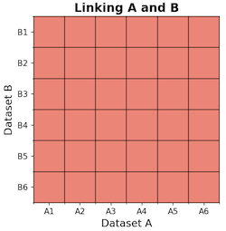

```
WARNING:recordlinkage:indexing - performance warning - A full index can result in large number of record pairs.
```

```
WARNING:recordlinkage:indexing - performance warning - A full index can result in large number of record pairs.
```

```
MultiIndex([('rec-1070-org',  'rec-561-dup-0'),
            ('rec-1070-org', 'rec-2642-dup-0'),
            ('rec-1070-org',  'rec-608-dup-0'),
            ('rec-1070-org', 'rec-3239-dup-0'),
            ('rec-1070-org', 'rec-2886-dup-0'),
            ('rec-1070-org', 'rec-4285-dup-0'),
            ('rec-1070-org',  'rec-929-dup-0'),
            ('rec-1070-org', 'rec-4833-dup-0'),
            ('rec-1070-org',  'rec-717-dup-0'),
            ('rec-1070-org', 'rec-3984-dup-0'),
            ...
            (  'rec-66-org',  'rec-670-dup-0'),
            (  'rec-66-org', 'rec-4134-dup-0'),
            (  'rec-66-org', 'rec-3866-dup-0'),
            (  'rec-66-org', 'rec-3152-dup-0'),
            (  'rec-66-org', 'rec-3363-dup-0'),
            (  'rec-66-org', 'rec-4495-dup-0'),
            (  'rec-66-org', 'rec-4211-dup-0'),
            (  'rec-66-org', 'rec-3131-dup-0'),
            (  'rec-66-org', 'rec-3815-dup-0'),
            (  'rec-66-org',  'rec-493-dup-0')],
           names=['rec_id_1', 'rec_id_2'], length=25000000)
```

### Comparison

**Comparison** refers to the process of evaluating all the possible candidate links in order to figure out all the attributes having the same value. In order to compare attributes, we need to specify (for each attribute):

- A **metric** to be used for evaluating the similarity between each pair of the same attributes of the different dataset
- A **threshold** to decide under which circumstances the metric shall return 1 or 0

The *similarity* is 1 in case of agreement or 0 in case of complete disagreement.

In this specific example we used the Jaro-Winkler method since, according to the documentation, it is faster than the Levenshtein distance and much faster than the Damerau-Levenshtein distance. Since comparing strings is computationally expensive, we chose a subset of attributes on which some errors are permitted.

```python
comparison = {'surname':['jarowinkler',0.85],
              'address_1':['jarowinkler',0.85],
              'address_2':['jarowinkler',0.85] }
exact = ['given_name', 'date_of_birth', 'suburb', 'state']

features_full = compare_records(candidate_links_full, dfA, dfB, comparison, exact)
features_full
```

| rec_id_1 | rec_id_2 | surname | address_1 | address_2 | given_name | date_of_birth | suburb | state |
| --- | --- | --- | --- | --- | --- | --- | --- | --- |
| rec-1070-org | rec-561-dup-0 | 0.0 | 0.0 | 0.0 | 0 | 0 | 0 | 0 |
|  | rec-2642-dup-0 | 0.0 | 0.0 | 0.0 | 0 | 0 | 0 | 1 |
|  | rec-608-dup-0 | 0.0 | 0.0 | 0.0 | 0 | 0 | 0 | 0 |
|  | rec-3239-dup-0 | 0.0 | 0.0 | 0.0 | 0 | 0 | 0 | 0 |
|  | rec-2886-dup-0 | 0.0 | 0.0 | 0.0 | 0 | 0 | 0 | 0 |
| ... | ... | ... | ... | ... | ... | ... | ... | ... |
| rec-66-org | rec-4495-dup-0 | 0.0 | 0.0 | 0.0 | 0 | 0 | 0 | 1 |
|  | rec-4211-dup-0 | 0.0 | 0.0 | 0.0 | 0 | 0 | 0 | 0 |
|  | rec-3131-dup-0 | 0.0 | 0.0 | 0.0 | 0 | 0 | 0 | 0 |
|  | rec-3815-dup-0 | 0.0 | 0.0 | 0.0 | 0 | 0 | 0 | 0 |
|  | rec-493-dup-0 | 0.0 | 0.0 | 0.0 | 0 | 0 | 0 | 0 |

25000000 rows × 7 columns

**Note**: no cardinality reduction is employed. The output of indexing phase has the same cardinality of the comparison phase. The columns represent the results of the comparison.

### Classification

In this phase, candidate links are classified into matches or non-matches. We analyze 3 different classification methods:

- **Deterministic approach** (no Machine Learning used)
- **Naive Bayes** (Supervised Learning)
- **Expectation-Conditional Maximisation** (Unsupervised Learning)

#### Deterministic approach

In the deterministic approach, we consider all the records that agree on at least a certain amount of attributes according to the rules we have previously specified.

```
7.0        1304
6.0        1860
5.0        1260
4.0         441
3.0         452
2.0       69727
1.0     5634539
0.0    19290417
dtype: int64
```

We notice that 1304 records have 7 common attributes, according to the comparison metrics that we chose. 1860 records have 6 common attributes instead, and so on.

We consider a match all the pairs that agree on at least 4 attributes. In the following table, the matches according to this rule are shown.

| rec_id_1 | rec_id_2 | surname | address_1 | address_2 | given_name | date_of_birth | suburb | state |
| --- | --- | --- | --- | --- | --- | --- | --- | --- |
| rec-1016-org | rec-1016-dup-0 | 1.0 | 1.0 | 0.0 | 1 | 1 | 1 | 0 |
| rec-4405-org | rec-4405-dup-0 | 1.0 | 1.0 | 1.0 | 1 | 1 | 1 | 1 |
| rec-1288-org | rec-1288-dup-0 | 1.0 | 1.0 | 1.0 | 1 | 1 | 0 | 1 |
| rec-3585-org | rec-3585-dup-0 | 1.0 | 1.0 | 1.0 | 1 | 1 | 1 | 1 |
| rec-298-org | rec-298-dup-0 | 1.0 | 0.0 | 0.0 | 1 | 1 | 1 | 1 |
| ... | ... | ... | ... | ... | ... | ... | ... | ... |
| rec-2153-org | rec-2153-dup-0 | 1.0 | 0.0 | 0.0 | 0 | 1 | 1 | 1 |
| rec-1604-org | rec-1604-dup-0 | 0.0 | 1.0 | 1.0 | 0 | 1 | 1 | 1 |
| rec-1003-org | rec-1003-dup-0 | 0.0 | 1.0 | 1.0 | 0 | 1 | 0 | 1 |
| rec-4883-org | rec-4883-dup-0 | 1.0 | 1.0 | 1.0 | 1 | 1 | 1 | 1 |
| rec-66-org | rec-66-dup-0 | 1.0 | 1.0 | 1.0 | 1 | 1 | 1 | 1 |

4865 rows × 7 columns

#### Naive Bayes

Naive Bayes is a supervised-learning algorithm that provides a method for computing the probability of a given hypotesis on prior knowledge. It is based on the assumption that all features are conditionally independent.

We initialise the NaiveBayesClassifier.

```python
nb_full = rl.NaiveBayesClassifier()
nb_full.fit(features_full, true_links)
```

We print also the parameters that are trained.

- p is the probability P(Match)
- m is the probability that P(x_i=1|Match)
- u is the probability that P(x_i=1|Non-Match)

```
p probability P(Match): 0.00019999999999999985

m probabilities P(x_i=1|Match): {'surname': {0.0: 0.14700001411999955, 1.0: 0.8529999858800007}, 'address_1': {0.0: 0.11280001548799944, 1.0: 0.8871999845120011}, 'address_2': {0.0: 0.23020001079199967, 1.0: 0.7697999892080011}, 'given_name': {0.0: 0.3426000062959999, 1.0: 0.6573999937040006}, 'date…

u probabilities P(x_i=1|Non-Match): {'surname': {0.0: 0.9951189437847974, 1.0: 0.004881056215203998}, 'address_1': {0.0: 0.9971519903941033, 1.0: 0.0028480096058983977}, 'address_2': {0.0: 0.9987709141788471, 1.0: 0.0012290858211543999}, 'given_name': {0.0: 0.9970409281816627, 1.0: 0.002959071818339…

weights of features: {'surname': {0.0: 0.14772104886367185, 1.0: 174.75725504307687}, 'address_1': {0.0: 0.11312218856768025, 1.0: 311.5157977959615}, 'address_2': {0.0: 0.230483294541333, 1.0: 626.3191519734385}, 'given_name': {0.0: 0.34361679306466497, 1.0: 222.1642575991257}, 'date_of_birth': {0.…
```

We tried to predict the matches starting by the output of the comparison phase, using the trained model. We know from the documentation that the total matches are 5000 and our model found 4958.

```
Predicted number of links: 4958
```

We predict the match probability for each pair in the dataset, since we apply the Full Index method.

```python
probs_bayes_full = nb_full.prob(features_full)
probs_bayes_full
```

```
rec_id_1      rec_id_2
rec-1070-org  rec-561-dup-0     5.362010e-10
              rec-2642-dup-0    3.086106e-08
              rec-608-dup-0     5.362010e-10
              rec-3239-dup-0    5.362010e-10
              rec-2886-dup-0    5.362010e-10
                                    ...
rec-66-org    rec-4495-dup-0    3.086106e-08
              rec-4211-dup-0    5.362010e-10
              rec-3131-dup-0    5.362010e-10
              rec-3815-dup-0    5.362010e-10
              rec-493-dup-0     5.362010e-10
Length: 25000000, dtype: float64
```

#### Expectation-Conditional Maximisation

Unsupervised learning with the ECM algorithm. This classifier doesn’t need training label since it is often hard to collect.

We initialise the Expectation-Conditional Maximisation classifier.

```python
ecm_full = rl.ECMClassifier()
ecm_full.fit(features_full)
```

We print the parameters that are trained (m, u and p).

```
p probability P(Match): 0.00019964038993562045

m probabilities P(x_i=1|Match): {'surname': {0.0: 0.14559845395438062, 1.0: 0.8544015460456198}, 'address_1': {0.0: 0.11167423011028436, 1.0: 0.8883257698897149}, 'address_2': {0.0: 0.22930633589775026, 1.0: 0.7706936641022502}, 'given_name': {0.0: 0.3415113651654586, 1.0: 0.6584886348345418}, 'date…

u probabilities P(x_i=1|Non-Match): {'surname': {0.0: 0.9951189185968193, 1.0: 0.0048810814031804844}, 'address_1': {0.0: 0.9971518971067167, 1.0: 0.002848102893281545}, 'address_2': {0.0: 0.9987708161888874, 1.0: 0.0012291838111130658}, 'given_name': {0.0: 0.9970409101739776, 1.0: 0.002959089826020…

weights of features: {'surname': {0.0: 0.1463126177519403, 1.0: 175.04349456022118}, 'address_1': {0.0: 0.11199319826228323, 1.0: 311.9008698685735}, 'address_2': {0.0: 0.22958854241730656, 1.0: 626.996269503714}, 'given_name': {0.0: 0.3425249271926735, 1.0: 222.53080289900313}, 'date_of_birth': {0.…
```

```
Predicted number of links: 4958
```

```
rec_id_1      rec_id_2
rec-1070-org  rec-561-dup-0     5.170889e-10
              rec-2642-dup-0    2.958100e-08
              rec-608-dup-0     5.170889e-10
              rec-3239-dup-0    5.170889e-10
              rec-2886-dup-0    5.170889e-10
                                    ...
rec-66-org    rec-4495-dup-0    2.958100e-08
              rec-4211-dup-0    5.170889e-10
              rec-3131-dup-0    5.170889e-10
              rec-3815-dup-0    5.170889e-10
              rec-493-dup-0     5.170889e-10
Length: 25000000, dtype: float64
```

### Evaluation

We compare the results of the deterministic method and the two ML-based ones (Naive Bayes and ECM)

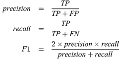

```
Deterministic approach

Confusion matrix:
 [[    4865      135]
 [       0 24995000]]
Fscore: 0.9863152559553979
Recall: 0.973
Precision: 1.0
```

```
Naive Bayes

Confusion matrix:
 [[    4954       46]
 [       4 24994996]]
Fscore: 0.9949789114279977
Recall: 0.9908
Precision: 0.9991932230738201
```

```
Expectation-Conditional Maximisation

Confusion matrix:
 [[    4954       46]
 [       4 24994996]]
Fscore: 0.9949789114279977
Recall: 0.9908
Precision: 0.9991932230738201
```

## Part 2 : Using a Block Index

### Indexing (Block)

Indexing is the process of creating all the possible links between the two datasets. In this specific example, we use a technique called **Blocking**, which groups together all the records that agree on AT LEAST one of the specified attributes.

We have decided to use **surname**, **date_of_birth** and **soc_sec_id** as discriminating variables. By doing that, the resulting records will agree on at least one of these attributes.

**Note**: the cardinality using the Block Index method is way less than the Full Index method.

```
MultiIndex([(  'rec-0-org',    'rec-0-dup-0'),
            (  'rec-0-org', 'rec-1505-dup-0'),
            (  'rec-0-org', 'rec-1636-dup-0'),
            (  'rec-0-org', 'rec-2074-dup-0'),
            (  'rec-0-org', 'rec-2683-dup-0'),
            (  'rec-0-org', 'rec-2724-dup-0'),
            (  'rec-0-org', 'rec-2894-dup-0'),
            (  'rec-1-org',    'rec-1-dup-0'),
            (  'rec-1-org', 'rec-1052-dup-0'),
            (  'rec-1-org', 'rec-2552-dup-0'),
            ...
            ('rec-999-org', 'rec-3685-dup-0'),
            ('rec-999-org',  'rec-370-dup-0'),
            ('rec-999-org', 'rec-3766-dup-0'),
            ('rec-999-org', 'rec-3862-dup-0'),
            ('rec-999-org', 'rec-3913-dup-0'),
            ('rec-999-org', 'rec-3940-dup-0'),
            ('rec-999-org', 'rec-4941-dup-0'),
            ('rec-999-org',  'rec-859-dup-0'),
            ('rec-999-org',  'rec-911-dup-0'),
            ('rec-999-org',  'rec-999-dup-0')],
           names=['rec_id_1', 'rec_id_2'], length=87132)
```

We verify that a pair of candidate links agree on the given attributes:

```
given_name               rachael
surname                     dent
street_number                  1
address_1            knox street
address_2        lakewood estate
suburb                    byford
postcode                    4129
state                        vic
date_of_birth           19280722
soc_sec_id               1683994
Name: rec-0-org, dtype: object
```

```
given_name               rachael
surname                     dent
street_number                  4
address_1            knox street
address_2        lakewood estate
suburb                    byford
postcode                    4129
state                        vic
date_of_birth           19280722
soc_sec_id               1683994
Name: rec-0-dup-0, dtype: object
```

### Comparison

We used the same metrics and threshold for each pair of attributes used in the previous experiment.

| rec_id_1 | rec_id_2 | surname | address_1 | address_2 | given_name | date_of_birth | suburb | state |
| --- | --- | --- | --- | --- | --- | --- | --- | --- |
| rec-0-org | rec-0-dup-0 | 1.0 | 1.0 | 1.0 | 1 | 1 | 1 | 1 |
|  | rec-1505-dup-0 | 1.0 | 0.0 | 0.0 | 0 | 0 | 0 | 0 |
|  | rec-1636-dup-0 | 1.0 | 0.0 | 0.0 | 0 | 0 | 0 | 0 |
|  | rec-2074-dup-0 | 1.0 | 0.0 | 0.0 | 0 | 0 | 0 | 1 |
|  | rec-2683-dup-0 | 1.0 | 0.0 | 0.0 | 0 | 0 | 0 | 0 |
| ... | ... | ... | ... | ... | ... | ... | ... | ... |
| rec-999-org | rec-3940-dup-0 | 1.0 | 0.0 | 0.0 | 0 | 0 | 0 | 0 |
|  | rec-4941-dup-0 | 1.0 | 0.0 | 0.0 | 0 | 0 | 0 | 0 |
|  | rec-859-dup-0 | 1.0 | 0.0 | 0.0 | 0 | 0 | 0 | 0 |
|  | rec-911-dup-0 | 1.0 | 0.0 | 0.0 | 0 | 0 | 0 | 1 |
|  | rec-999-dup-0 | 1.0 | 1.0 | 1.0 | 1 | 1 | 1 | 1 |

87132 rows × 7 columns

### Classification

#### Deterministic approach

Also in this case, we consider a match all the pairs that agree on at least 4 attributes.

```
7.0     1304
6.0     1857
5.0     1257
4.0      438
3.0      268
2.0    18304
1.0    63704
dtype: int64
```

#### Naive Bayes

```python
# Initialise the NaiveBayesClassifier.
nb_block = rl.NaiveBayesClassifier()
nb_block.fit(features_block, true_links)
```

```
p probability P(Match): 0.05726943028967549

m probabilities P(x_i=1|Match): {'surname': {0.0: 0.1462925993469899, 1.0: 0.8537074006530102}, 'address_1': {0.0: 0.11302606761418561, 1.0: 0.8869739323858145}, 'address_2': {0.0: 0.23026053185328524, 1.0: 0.7697394681467138}, 'given_name': {0.0: 0.34268537704667806, 1.0: 0.6573146229533218}, 'date…

u probabilities P(x_i=1|Non-Match): {'surname': {0.0: 0.0077305166474385435, 1.0: 0.9922694833525615}, 'address_1': {0.0: 0.9970904032112915, 1.0: 0.002909596788708342}, 'address_2': {0.0: 0.9987338986176765, 1.0: 0.001266101382323047}, 'given_name': {0.0: 0.9970173589710086, 1.0: 0.0029826410289921…

weights of features: {'surname': {0.0: 18.924039106165434, 1.0: 0.8603584157084078}, 'address_1': {0.0: 0.11335588754055481, 1.0: 304.8442780209312}, 'address_2': {0.0: 0.2305524346094423, 1.0: 607.960372600173}, 'given_name': {0.0: 0.3437105422119764, 1.0: 220.38006470240086}, 'date_of_birth': {0.0…
```

```
Predicted number of links: 5107
```

```
rec_id_1     rec_id_2
rec-0-org    rec-0-dup-0       1.000000e+00
             rec-1505-dup-0    9.443910e-07
             rec-1636-dup-0    9.443910e-07
             rec-2074-dup-0    5.426506e-05
             rec-2683-dup-0    9.443910e-07
                                   ...
rec-999-org  rec-3940-dup-0    9.443910e-07
             rec-4941-dup-0    9.443910e-07
             rec-859-dup-0     9.443910e-07
             rec-911-dup-0     5.426506e-05
             rec-999-dup-0     1.000000e+00
Length: 87132, dtype: float64
```

#### Expectation-Conditional Maximisation

```python
# Initialise the Expectation-Conditional Maximisation classifier.
ecm_block = rl.ECMClassifier()
ecm_block.fit(features_block)
```

```
p probability P(Match): 0.05890218346289975

m probabilities P(x_i=1|Match): {'surname': {0.0: 0.17208594081201783, 1.0: 0.8279140591879811}, 'address_1': {0.0: 0.1364062789961936, 1.0: 0.863593721003806}, 'address_2': {0.0: 0.25072440372196897, 1.0: 0.7492755962780303}, 'given_name': {0.0: 0.36109752267741557, 1.0: 0.6389024773225834}, 'date_…

u probabilities P(x_i=1|Non-Match): {'surname': {0.0: 0.00587574265639725, 1.0: 0.9941242573436027}, 'address_1': {0.0: 0.9971608673018983, 1.0: 0.002839132698101932}, 'address_2': {0.0: 0.9987863491894582, 1.0: 0.001213650810542423}, 'given_name': {0.0: 0.9970001958451015, 1.0: 0.002999804154898576…

weights of features: {'surname': {0.0: 29.287521744108087, 1.0: 0.832807421277747}, 'address_1': {0.0: 0.13679465718031986, 1.0: 304.1751875779358}, 'address_2': {0.0: 0.25102906535060127, 1.0: 617.3732920288273}, 'given_name': {0.0: 0.3621840037567228, 1.0: 212.98139622857641}, 'date_of_birth': {0.…
```

```
Predicted number of links: 5110
```

```
rec_id_1     rec_id_2
rec-0-org    rec-0-dup-0       1.000000
             rec-1505-dup-0    0.000002
             rec-1636-dup-0    0.000002
             rec-2074-dup-0    0.000079
             rec-2683-dup-0    0.000002
                                 ...
rec-999-org  rec-3940-dup-0    0.000002
             rec-4941-dup-0    0.000002
             rec-859-dup-0     0.000002
             rec-911-dup-0     0.000079
             rec-999-dup-0     1.000000
Length: 87132, dtype: float64
```

### Evaluation

```
Deterministic approach

Confusion matrix:
 [[ 4856   144]
 [    0 82132]]
Fscore: 0.9853896103896103
Recall: 0.9712
Precision: 1.0
```

```
Naive Bayes

Confusion matrix:
 [[ 4956    44]
 [  151 81981]]
Fscore: 0.9807064410804394
Recall: 0.9912
Precision: 0.9704327393773252
```

```
Expectation-Conditional Maximisation

Confusion matrix:
 [[ 4959    41]
 [  151 81981]]
Fscore: 0.9810089020771513
Recall: 0.9918
Precision: 0.9704500978473581
```

## Results Analysis

From the previous two experiments, we noticed that:

- The cardinality of the candidate links with Full Index method is 25000000, with the Block Index is 87132.
- This leads to a significative difference in the execution time:
  - The Full Index takes 160 seconds circa for the comparison phase; the Block Index takes about 0.56 seconds instead.
  - Naive Bayes takes about 150s with Full Index and 0.23s with Block Index.
  - ECM takes about 92s with Full Index and 0.29s with Block Index.
- This does not lead to a significative difference in the evaluation results:
  - The Full Index method brings a very small increase in the Fscore.

We do not consider this result to be meaningful. Blocking should always be preferred, provided that it is clear what attributes should be used in the index.

# Experiment 2: Training and Testing our models for evaluating re-usability

In this experiment, we ﬁrst train our models on a dataset. Then, we test the models on another one with the same attributes but with different records and a different duplicate distribution. We do that in order to investigate the *re-usability* of the models we create, and to evaluate their applications in real-case scenarios.

## Part 1 : Training

### Dataset description

```
Loading data...
5000 records in dataset A
1934 links between dataset A and A
```

| rec_id | given_name | surname | street_number | address_1 | address_2 | suburb | postcode | state | date_of_birth | soc_sec_id |
| --- | --- | --- | --- | --- | --- | --- | --- | --- | --- | --- |
| rec-2778-org | sarah | bruhn | 44 | forbes street | wintersloe | kellerberrin | 4510 | vic | 19300213 | 7535316 |
| rec-712-dup-0 | jacob | lanyon | 5 | milne cove | wellwod | beaconsfield upper | 2602 | vic | 19080712 | 9497788 |
| rec-1321-org | brinley | efthimiou | 35 | sturdee crescent | tremearne | scarborough | 5211 | qld | 19940319 | 6814956 |
| rec-3004-org | aleisha | hobson | 54 | oliver street | inglewood | toowoomba | 3175 | qld | 19290427 | 5967384 |
| rec-1384-org | ethan | gazzola | 49 | sheaffe street | bimby vale | port pirie | 3088 | sa | 19631225 | 3832742 |
| ... | ... | ... | ... | ... | ... | ... | ... | ... | ... | ... |
| rec-1487-org | thomas | green | 44 | tuthill place | holmeleigh | bonny hills | 4740 | vic | 19420210 | 9334580 |
| rec-1856-org | james | mcneill | 42 | archibald street | NaN | evans head | 2250 | nsw | 19011207 | 4837378 |
| rec-3307-org | paige | lock | 7 | a'beckett street | camboon | carina heights | 2290 | nsw | 19871002 | 5142242 |
| rec-227-org | antonio | collier | 25 | govett place | the rocks | broken hill | 2304 | qld | 19400225 | 3973395 |
| rec-1143-org | harry | ryan | 30 | van raalte place | anana | preston west | 2572 | wa | 19250425 | 6392122 |

5000 rows × 10 columns

We notice that the records having the same numeric id represent the same entity but with some errors in various attributes.

```
given_name                    jacob
surname                      lanyon
street_number                     5
address_1                milne cove
address_2                  wellwood
suburb           beaconsfield upper
postcode                       2602
state                           vic
date_of_birth              19080712
soc_sec_id                  9497788
Name: rec-712-org, dtype: object
```

```
given_name                    jacob
surname                      lanyon
street_number                     5
address_1                milne cove
address_2                   wellwod
suburb           beaconsfield upper
postcode                       2602
state                           vic
date_of_birth              19080712
soc_sec_id                  9497788
Name: rec-712-dup-0, dtype: object
```

```
given_name                    jacob
surname                      lanyln
street_number                     5
address_1                milne cove
address_2                  wellwood
suburb           beaconsfieod upper
postcode                       2602
state                           vic
date_of_birth              19080712
soc_sec_id                  9497788
Name: rec-712-dup-1, dtype: object
```

### Indexing (Block)

We have decided to use **surname**, **date_of_birth** and **soc_sec_id** as discriminating variables. It's important to notice that the discriminating variables are the same throughout different experiments.

```
MultiIndex([(    'rec-0-org', 'rec-3741-dup-0'),
            (    'rec-0-org',   'rec-3741-org'),
            (   'rec-10-org',   'rec-2162-org'),
            (   'rec-10-org',    'rec-343-org'),
            (   'rec-10-org',    'rec-956-org'),
            ('rec-100-dup-0',    'rec-100-org'),
            ('rec-100-dup-1',  'rec-100-dup-0'),
            ('rec-100-dup-1',    'rec-100-org'),
            ('rec-100-dup-2',  'rec-100-dup-0'),
            ('rec-100-dup-2',  'rec-100-dup-1'),
            ...
            (  'rec-998-org',   'rec-1578-org'),
            (  'rec-998-org',   'rec-2112-org'),
            (  'rec-998-org',   'rec-2273-org'),
            (  'rec-998-org',   'rec-2670-org'),
            (  'rec-998-org',    'rec-305-org'),
            (  'rec-998-org',    'rec-345-org'),
            (  'rec-998-org',   'rec-3803-org'),
            (  'rec-998-org',   'rec-3936-org'),
            (  'rec-998-org',    'rec-622-org'),
            (  'rec-999-org',   'rec-3297-org')],
           names=['rec_id_1', 'rec_id_2'], length=50929)
```

We show a pair of candidate links in order to verify that at least one of the values of the discriminating variables are equal.

```python
df.loc[candidate_links[0][0]]
```

```
given_name              annabelle
surname                  friswell
street_number                 205
address_1            meares place
address_2        sunningdale farm
suburb              wildes meadow
postcode                     7018
state                          wa
date_of_birth            19761129
soc_sec_id                9016980
Name: rec-0-org, dtype: object
```

```python
df.loc[candidate_links[0][1]]
```

```
given_name            michael
surname              shepherd
street_number              70
address_1        hurry nplace
address_2            tintagel
suburb                penguin
postcode                 4179
state                     vic
date_of_birth        19761129
soc_sec_id            8270855
Name: rec-3741-dup-0, dtype: object
```

### Comparison

We used the same metrics and threshold used in the first experiment.

| rec_id_1 | rec_id_2 | surname | address_1 | address_2 | given_name | date_of_birth | suburb | state |
| --- | --- | --- | --- | --- | --- | --- | --- | --- |
| rec-0-org | rec-3741-dup-0 | 0.0 | 0.0 | 0.0 | 0 | 1 | 0 | 0 |
|  | rec-3741-org | 0.0 | 0.0 | 0.0 | 0 | 1 | 0 | 0 |
| rec-10-org | rec-2162-org | 1.0 | 0.0 | 0.0 | 0 | 0 | 0 | 0 |
|  | rec-343-org | 1.0 | 0.0 | 0.0 | 0 | 0 | 0 | 0 |
|  | rec-956-org | 1.0 | 0.0 | 0.0 | 0 | 0 | 0 | 0 |
| ... | ... | ... | ... | ... | ... | ... | ... | ... |
| rec-998-org | rec-345-org | 1.0 | 0.0 | 0.0 | 0 | 0 | 0 | 1 |
|  | rec-3803-org | 1.0 | 0.0 | 0.0 | 0 | 0 | 0 | 1 |
|  | rec-3936-org | 1.0 | 0.0 | 0.0 | 0 | 0 | 0 | 0 |
|  | rec-622-org | 1.0 | 0.0 | 0.0 | 0 | 0 | 0 | 0 |
| rec-999-org | rec-3297-org | 1.0 | 0.0 | 0.0 | 0 | 0 | 0 | 0 |

50929 rows × 7 columns

### Classification

We train our ML models in order to acquire knowledge to classify records in the test set, considering the weights of the attributes.

#### Naive Bayes

```python
# Initialise the NaiveBayesClassifier.
nb = rl.NaiveBayesClassifier()
nb.fit(features, true_links)
```

```
p probability P(Match): 0.03769954250034364

m probabilities P(x_i=1|Match): {'surname': {0.0: 0.19739586485459734, 1.0: 0.8026041351454025}, 'address_1': {0.0: 0.12031253955077714, 1.0: 0.879687460449223}, 'address_2': {0.0: 0.2984375209960916, 1.0: 0.7015624790039081}, 'given_name': {0.0: 0.3880208449978287, 1.0: 0.6119791550021711}, 'date_o…

u probabilities P(x_i=1|Non-Match): {'surname': {0.0: 0.006304966409006646, 1.0: 0.9936950335909945}, 'address_1': {0.0: 0.9959803281194052, 1.0: 0.004019671880594699}, 'address_2': {0.0: 0.9986533065410298, 1.0: 0.0013466934589700125}, 'given_name': {0.0: 0.9961435634428644, 1.0: 0.0038564365571367…

weights of features: {'surname': {0.0: 31.3079962761764, 1.0: 0.8076966352996334}, 'address_1': {0.0: 0.12079810830997982, 1.0: 218.84558903824646}, 'address_2': {0.0: 0.29883996682469327, 1.0: 520.9518724034511}, 'given_name': {0.0: 0.38952301579578924, 1.0: 158.6903209569583}, 'date_of_birth': {0.…
```

#### Expectation-Conditional Maximisation

```python
# Initialise the Expectation-Conditional Maximisation classifier.
ecm = rl.ECMClassifier()
ecm.fit(features)
```

```
p probability P(Match): 0.04422886741322979

m probabilities P(x_i=1|Match): {'surname': {0.0: 0.30542655786279255, 1.0: 0.694573442137208}, 'address_1': {0.0: 0.2468825894881691, 1.0: 0.7531174105118315}, 'address_2': {0.0: 0.40047239991837746, 1.0: 0.5995276000816229}, 'given_name': {0.0: 0.4751710465591838, 1.0: 0.5248289534408166}, 'date_o…

u probabilities P(x_i=1|Non-Match): {'surname': {0.0: 3.4736045678538596e-07, 1.0: 0.9999996526395413}, 'address_1': {0.0: 0.9961053266705839, 1.0: 0.0038946733294151813}, 'address_2': {0.0: 0.9987150895414244, 1.0: 0.0012849104585748773}, 'given_name': {0.0: 0.9962650126166345, 1.0: 0.0037349873833…

weights of features: {'surname': {0.0: 879278.4322353012, 1.0: 0.6945736834046412}, 'address_1': {0.0: 0.24784787600058097, 1.0: 193.37113714359157}, 'address_2': {0.0: 0.4009876331219353, 1.0: 466.59095665434324}, 'given_name': {0.0: 0.47695245797217506, 1.0: 140.51692805671993}, 'date_of_birth': {…
```

## Part 2 : Testing

### Dataset description

```
Loading data...
5000 records in dataset A
6538 links between dataset A and A
```

| rec_id | given_name | surname | street_number | address_1 | address_2 | suburb | postcode | state | date_of_birth | soc_sec_id |
| --- | --- | --- | --- | --- | --- | --- | --- | --- | --- | --- |
| rec-1496-org | mitchell | green | 7 | wallaby place | delmar | cleveland | 2119 | sa | 19560409 | 1804974 |
| rec-552-dup-3 | harley | mccarthy | 177 | pridhamstreet | milton | marsden | 3165 | nsw | 19080419 | 6089216 |
| rec-988-dup-1 | madeline | mason | 54 | hoseason street | lakefront retrmnt vlge | granville | 4881 | nsw | 19081128 | 2185997 |
| rec-1716-dup-1 | isabelle | NaN | 23 | gundulu place | currin ga | utakarra | 2193 | wa | 19921119 | 4314184 |
| rec-1213-org | taylor | hathaway | 7 | yuranigh court | brentwood vlge | NaN | 4220 | nsw | 19991207 | 9144092 |
| ... | ... | ... | ... | ... | ... | ... | ... | ... | ... | ... |
| rec-937-org | jack | campbell | 169 | marr street | rhosewyn | oakleigh | 3356 | vic | 19770109 | 1485686 |
| rec-1200-dup-0 | william | lazaroff | 12 | leah ylose | milwlood | forbes | 7256 | qld | NaN | 8072193 |
| rec-1756-org | destynii | bowerman | 12 | halford crescent | sutton | nollamara | 2431 | qld | 19880821 | 6089424 |
| rec-1444-org | gianni | dooley | 38 | ashburton circuit | brentwood vlge | ryde | 6025 | qld | 19371212 | 5854405 |
| rec-993-dup-0 | jake | westbrook | 231 | booroondar a street | jodayne | salisbury east | 2074 | nsw | 19001115 | 2330929 |

5000 rows × 10 columns

### Indexing

```python
candidate_links = indexing_dataset(df, None, ['surname','date_of_birth', 'soc_sec_id'])
candidate_links
```

```
MultiIndex([(   'rec-1-org', 'rec-1963-dup-0'),
            (   'rec-1-org',  'rec-567-dup-1'),
            (   'rec-1-org',  'rec-910-dup-1'),
            ('rec-10-dup-0',   'rec-10-dup-2'),
            ('rec-10-dup-1',   'rec-10-dup-0'),
            ('rec-10-dup-1',   'rec-10-dup-2'),
            ('rec-10-dup-1', 'rec-1411-dup-0'),
            ('rec-10-dup-1', 'rec-1411-dup-1'),
            ('rec-10-dup-1', 'rec-1411-dup-2'),
            ('rec-10-dup-1',   'rec-1411-org'),
            ...
            ( 'rec-997-org',   'rec-66-dup-0'),
            ( 'rec-997-org',     'rec-66-org'),
            ( 'rec-997-org',  'rec-724-dup-0'),
            ( 'rec-997-org',  'rec-724-dup-4'),
            ( 'rec-997-org',    'rec-724-org'),
            ( 'rec-997-org',    'rec-849-org'),
            ( 'rec-997-org',  'rec-997-dup-0'),
            ( 'rec-999-org',    'rec-234-org'),
            ( 'rec-999-org',  'rec-679-dup-1'),
            ( 'rec-999-org',    'rec-679-org')],
           names=['rec_id_1', 'rec_id_2'], length=40470)
```

### Comparison

Also in this case, we used the same metrics and threshold used in the previous experiments.

| rec_id_1 | rec_id_2 | surname | address_1 | address_2 | given_name | date_of_birth | suburb | state |
| --- | --- | --- | --- | --- | --- | --- | --- | --- |
| rec-1-org | rec-1963-dup-0 | 1.0 | 0.0 | 0.0 | 0 | 0 | 0 | 0 |
|  | rec-567-dup-1 | 1.0 | 0.0 | 0.0 | 0 | 0 | 0 | 1 |
|  | rec-910-dup-1 | 1.0 | 0.0 | 0.0 | 0 | 0 | 0 | 1 |
| rec-10-dup-0 | rec-10-dup-2 | 0.0 | 0.0 | 1.0 | 0 | 1 | 1 | 1 |
| rec-10-dup-1 | rec-10-dup-0 | 0.0 | 0.0 | 1.0 | 0 | 1 | 1 | 1 |
| ... | ... | ... | ... | ... | ... | ... | ... | ... |
| rec-997-org | rec-849-org | 1.0 | 0.0 | 0.0 | 0 | 0 | 0 | 1 |
|  | rec-997-dup-0 | 1.0 | 1.0 | 1.0 | 0 | 1 | 1 | 1 |
| rec-999-org | rec-234-org | 1.0 | 0.0 | 0.0 | 0 | 0 | 0 | 0 |
|  | rec-679-dup-1 | 1.0 | 0.0 | 0.0 | 0 | 0 | 0 | 0 |
|  | rec-679-org | 1.0 | 0.0 | 0.0 | 0 | 0 | 0 | 0 |

40470 rows × 7 columns

### Classification

#### Deterministic approach

We consider a match all the pairs that agree on at least 4 attributes.

```
7.0      969
6.0     2066
5.0     1955
4.0     1007
3.0      451
2.0     6929
1.0    27093
dtype: int64
```

| rec_id_1 | rec_id_2 | surname | address_1 | address_2 | given_name | date_of_birth | suburb | state |
| --- | --- | --- | --- | --- | --- | --- | --- | --- |
| rec-10-dup-0 | rec-10-dup-2 | 0.0 | 0.0 | 1.0 | 0 | 1 | 1 | 1 |
| rec-10-dup-1 | rec-10-dup-0 | 0.0 | 0.0 | 1.0 | 0 | 1 | 1 | 1 |
|  | rec-10-dup-2 | 1.0 | 0.0 | 1.0 | 0 | 1 | 1 | 1 |
| rec-10-org | rec-10-dup-0 | 0.0 | 1.0 | 1.0 | 0 | 1 | 1 | 1 |
|  | rec-10-dup-1 | 1.0 | 0.0 | 1.0 | 0 | 1 | 1 | 1 |
| ... | ... | ... | ... | ... | ... | ... | ... | ... |
| rec-995-dup-0 | rec-995-org | 1.0 | 1.0 | 1.0 | 1 | 1 | 1 | 1 |
| rec-996-dup-1 | rec-996-dup-0 | 1.0 | 1.0 | 1.0 | 0 | 1 | 0 | 1 |
| rec-996-org | rec-996-dup-0 | 1.0 | 1.0 | 1.0 | 0 | 1 | 1 | 1 |
|  | rec-996-dup-1 | 1.0 | 1.0 | 1.0 | 1 | 1 | 0 | 1 |
| rec-997-org | rec-997-dup-0 | 1.0 | 1.0 | 1.0 | 0 | 1 | 1 | 1 |

5997 rows × 7 columns

#### Naive Bayes

```
Predicted number of links: 6428
```

#### Expectation-Conditional Maximisation

```
Predicted number of links: 6750
```

### Evaluation

```
Deterministic approach

Confusion matrix:
 [[ 5997   541]
 [    0 33932]]
Fscore: 0.9568408456322298
Recall: 0.9172529825634751
Precision: 1.0
```

```
Naive Bayes

Confusion matrix:
 [[ 6364   174]
 [   64 33868]]
Fscore: 0.9816443004781737
Recall: 0.9733863566840012
Precision: 0.9900435594275047
```

```
Expectation-Conditional Maximisation

Confusion matrix:
 [[ 6436   102]
 [  314 33618]]
Fscore: 0.9686935580975315
Recall: 0.9843988987457938
Precision: 0.9534814814814815
```

## Results analysis

While the results of the Confusion Matrices may be a little flawed due to the "toy-like" nature of our datasets, we think that the approach can work in real-case scenarios. However, it does require:

- a large amount of data (which is not a problem anymore)
- high computational power (again, not a problem anymore)
- the **true links**, which may not be always available in pratice. While it may be easy for humans to create true links, the sheer amount of time required for datasets with millions (or more) of records may be too high. The key to solving these problem may be to investigate the usage of unsupervised methods for non labelled problems, so that true links are not required in the first place.